# Årsrapport fangster MV-LF

2024-09-18

# 1 Karup Å systemet

## 1.1 MV-LF

Vi betragter fangstdata fra MV-LF i Karup Å.

Overblik over fangstdata for 2024

[output not shown]

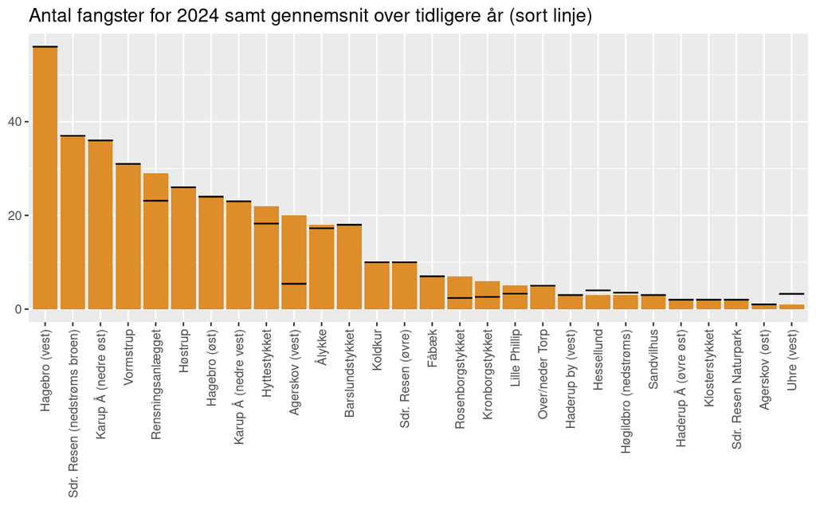

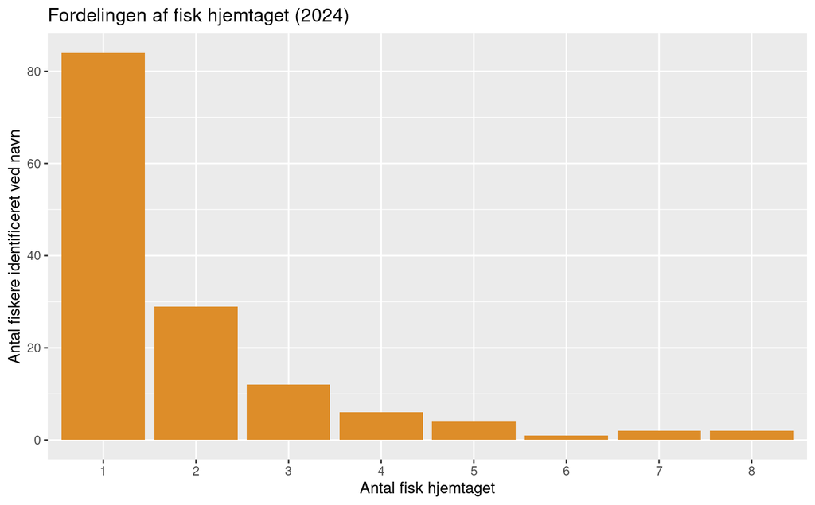

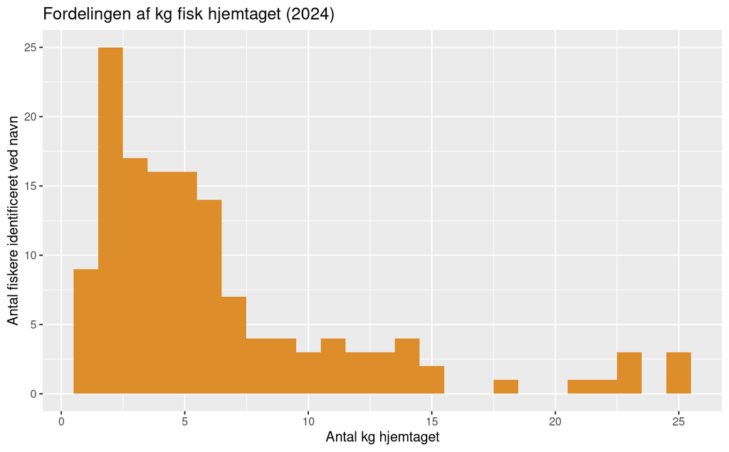

## 1.2 Alle foreninger

Vi kigger her på fangstdata for hele Karup Å systemet

Overblik over fangstdata for 2024

| Antal fanget | 1410 |
| --- | --- |
| Genudsat | 36 % |
| Gennesnitsvægt | 3.15 |
| Gennesnitsvægt hjemtaget | 3.59 |
| Gennesnitsvægt genudsat | 2.34 |
| Største havørred hjemtaget | 9.2 kg, 89 cm af Casper Birkegaard Pedersen og Jonas Weiss Gustavsen på Flue |
| Største havørred genudsat | 7.97 kg, 87 cm af Georg Vinther og Jan Mark på Spin |

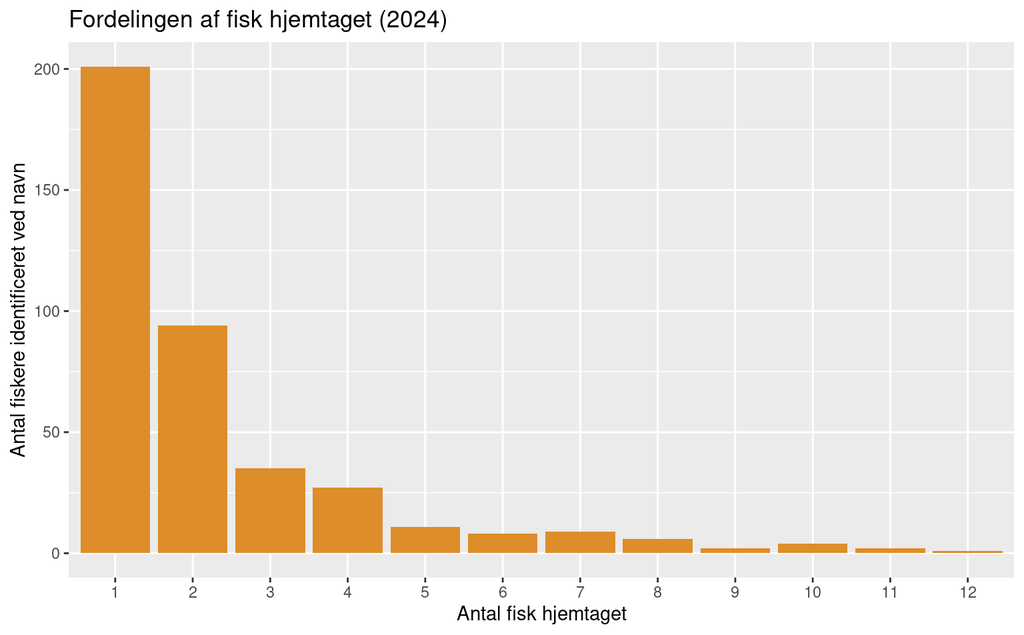

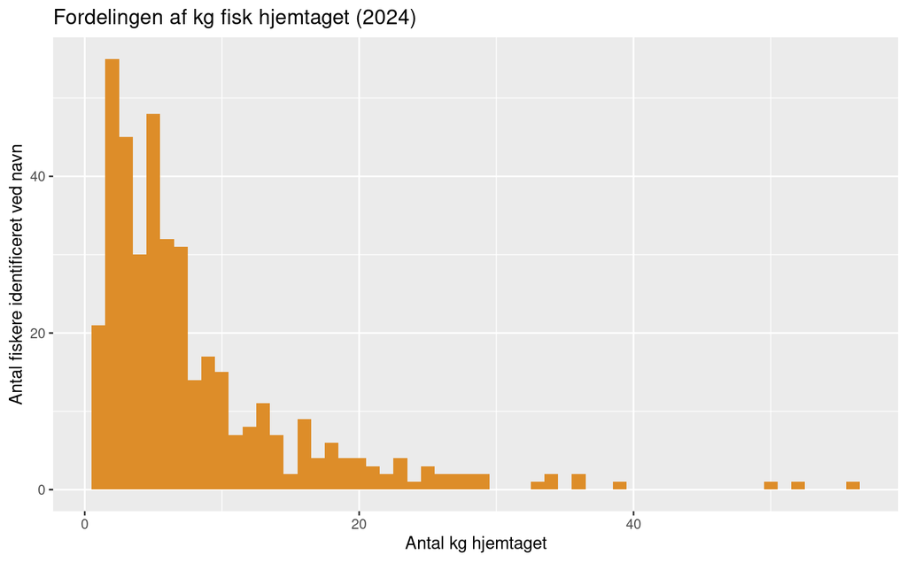

### 1.2.1 Effekter af kvoter

Der har været en diskussion omkring mådehold ved åen. For at holde denne diskussion på rette spor er lavet følgende analyse. Bemærk denne analyse er ikke ment som et argument for eller imod kvoter, men kan bruges til at holde diskussionen i forhold til faktiske data.

Hvis vi antager at der laves et kvote system hvor max $y$ antal fisk må hjemtages over $x$ cm, kan der givet dette års fangster udregnes hvad effekten af at indføre et kvotesystem ville have været.

Antagelser

- Kigger på fangster for nuværende år.
- Vi filtrer fangsterne så kun kigger på hjemtaget fisk.
- Vi kigger herefter på fisk over grænsen i cm og fjerner de første fangster givet et maks antal, der må fanges per fisker.
- Vi har herefter fangsterne der (hvis kvoten gælder) skulle have være genudsat.
- Vi filtrer for hunner.
- For hver fisk estimeres vægt og antal æg fisken ville have lagt.
- Det antages at 0.25% - 1% af disse æg bliver til tilbagevendende fisk (er ikke sikker på disse tal), dvs. gennemsnitligt 0.5%.

Estimat af antal æg givet havørredens længde (kilde ukendt)

| Længde | Antal æg |
| --- | --- |
| 30 | 700 |
| 40 | 1700 |
| 50 | 3200 |
| 60 | 5500 |
| 70 | 8700 |
| 80 | 12900 |
| 90 | 18300 |

Effekten af kvoterne kan ses i nedenstående tabel, fx hvis man kun måtte hjemtage 3 fisk over 70 cm vil effekten være at 8 fisk ville have været genudsat, disse vejede tilsammen 42.61 kg. Fiskene ville lægge 87494 æg der ville give ca 437 [219, 875] fisk som vente tilbage (intervallet er givet i firkantet parenteser). Bemærk at hvis er optræder nuller alle steder under effekt tallene betyder det at kvoterne ikke har nogen effekt.

Effekt af kvoter

| Kvote >cm | Kvote Max antal | Effekt Fisk | Effekt Kg | Effekt Æg | Effekt Retur |
| --- | --- | --- | --- | --- | --- |
| 70 | 1 | 51 | 264.91 | 545779 | 2729 [1364, 5458] |
| 70 | 2 | 18 | 95.40 | 194712 | 974 [487, 1947] |
| 70 | 3 | 8 | 42.61 | 87494 | 437 [219, 875] |
| 70 | 4 | 3 | 16.31 | 33672 | 168 [84, 337] |
| 70 | 5 | 1 | 4.40 | 9443 | 47 [24, 94] |
| 75 | 1 | 10 | 58.56 | 122654 | 613 [307, 1227] |
| 75 | 2 | 1 | 5.71 | 12431 | 62 [31, 124] |
| 75 | 3 | 0 | 0.00 | 0 | 0 [0, 0] |
| 75 | 4 | 0 | 0.00 | 0 | 0 [0, 0] |
| 75 | 5 | 0 | 0.00 | 0 | 0 [0, 0] |